# TRABAJO 2 TEORIA DE LA DECISION

Ángela

2024-12-05

```r
source("teoriadecision_funciones_multicriterio.R")
source("teoriadecision_funciones_multicriterio_diagram.R")
source("teoriadecision_funciones_multicriterio_utiles.R")
```

# Enunciado del Problema

Una familia está en proceso de seleccionar su futura vivienda y necesita decidir entre cinco alternativas disponibles las cuales tienen características distintas:

- **Casa en el Pueblo**
- **Casa en la Ciudad**
- **Casa en las Afueras**
- **Casa en la playa**
- **Casa en el Campo**

Para ello, la familia ha identificado seis criterios principales que considera importantes para tomar su decisión:

1. **Ubicación**: Proximidad a centros educativos, lugares de trabajo y servicios esenciales.Puntuamos este criterios de 0 a 10, siendo esta última la mejor ubicación.
2. **Precio**: Costo de adquisición y condiciones de financiamiento disponibles.Trabajamos con miles de euros.
3. **Tamaño y Distribución**: Superficie total de la vivienda y la disposición de sus espacios.Trabajaremos entre criterio con unidades en metros cuadrados.
4. **Seguridad**: Nivel de seguridad del área, incluyendo índices de delincuencia y disponibilidad de sistemas de vigilancia.Puntuamos este criterios de 0 a 10, siendo esta última la mejor.
5. **Infraestructura y Servicios**: Calidad y disponibilidad de servicios básicos como agua, electricidad, internet, transporte público y áreas verdes cercanas.Puntuamos este criterios de 0 a 10, siendo esta última la mejor.
6. **Estado de la Vivienda**: Condiciones generales de la propiedad, incluyendo si es nueva o usada, posibles necesidades de remodelación y materiales de construcción.Puntuamos este criterios de 0 a 10, siendo esta última la mejor.

Tras haber visitado las distintas opciones (alternativas) y hacer un estudio basándonos en los criterios, obtenemos que:

#### **A1: Casa en el pueblo**

- **Ubicación:** 9
- **Precio:** 120
- **Tamaño y distribución:** 70 m²
- **Seguridad:** 6
- **Infraestuctura y vivienda:** 9
- **Estado de la vivienda:** 8

#### **A2: Casa en la Ciudad**

- **Ubicación**: 10 (proximidad máxima a servicios esenciales)
- **Precio**: 250
- **Tamaño y distribución**: 85 m²
- **Seguridad**: 7
- **Infraestructura y servicios**: 10 (calidad máxima de servicios básicos)
- **Estado de la vivienda**: 9

#### **A3: Casa en las Afueras**

- **Ubicación**: 8 (moderada cercanía a centros educativos y laborales)
- **Precio**: 200
- **Tamaño y distribución**: 125 m²
- **Seguridad**: 8 (barrios más tranquilos)
- **Infraestructura y servicios**: 7
- **Estado de la vivienda**: 7

#### **A4: Casa en la Playa**

- **Ubicación**: 7 (alejada de centros urbanos)
- **Precio**: 300
- **Tamaño y distribución**: 110 m²
- **Seguridad**: 4 (menor vigilancia en áreas remotas)
- **Infraestructura y servicios**: 6 (limitaciones de servicios básicos en zonas costeras)
- **Estado de la vivienda**: 9

#### **A5: Casa en el Campo**

- **Ubicación**: 6 (mayor distancia de servicios esenciales)
- **Precio**: 160
- **Tamaño y distribución**: 140 m²
- **Seguridad**: 9 (entornos más seguros y tranquilos)
- **Infraestructura y servicios**: 7
- **Estado de la vivienda**: 8

Los pesos serían los siguientes:  
- **Ubicación**: 4  
La proximidad a servicios esenciales y centros educativos/laborales es crucial.  
- **Precio**: 3.5  
El presupuesto es un factor determinante en cualquier decisión de compra.  
- **Tamaño y Distribución**: 2.5  
La amplitud y funcionalidad de los espacios son relevantes, pero no tanto como otros criterios.  
- **Seguridad**: 3.5  
La tranquilidad y protección de la familia son esenciales.  
- **Infraestructura y Servicios**: 2  
La disponibilidad de servicios básicos impacta en la calidad de vida.  
- **Estado de la Vivienda**: 2.5  
Las condiciones de la casa son importantes, pero pueden ajustarse con remodelaciones si el presupuesto lo permite.

Recogiendo todos los datos que hemos visto hasta ahora obtenemos la siguiente tabla:

```r
library(kableExtra)

# Criterios:
criterios <- c("Ubicación", "Precio", "Tamaño y Distribución", "Seguridad", "Infraestructura y Servicios", "Estado de la Vivienda")

#Objetivo para cada criterio:
min_max <- c("Max", "Min", "Max", "Max", "Max", "Max")

#Alternativas:
alternativas <- c("A1", "A2", "A3", "A4", "A5")
A1 <- c(9, 120, 70, 6, 9, 8)
A2 <- c(10, 250, 85, 7, 10, 9)
A3 <- c(8, 200, 125, 8, 7, 7)
A4 <- c(7, 300, 110, 4, 6, 9)
A5 <- c(6, 160, 140, 9, 7, 8)
tipo <- c("II", "III", "II", "II", "II", "II") # Ejemplo de clasificación

# Parámetros
q <- c(1, 0, 1, 1, 1, 1) # Valores de q
p <- c(4, 3.5, 2.5, 3.5, 2, 2.5) # Valores de los pesos
s <- c(3, 50, 20, 2, 2, 2) # Valores de s

# Crear tabla
tabla <- data.frame(
  "Criterios" = criterios, "Min/Max" = min_max, A1, A2, A3, A4, A5,tipo, p, q, s )

print(tabla)
```

```
##                     Criterios Min.Max  A1  A2  A3  A4  A5 tipo   p q  s
## 1                   Ubicación     Max   9  10   8   7   6   II 4.0 1  3
## 2                      Precio     Min 120 250 200 300 160  III 3.5 0 50
## 3       Tamaño y Distribución     Max  70  85 125 110 140   II 2.5 1 20
## 4                   Seguridad     Max   6   7   8   4   9   II 3.5 1  2
## 5 Infraestructura y Servicios     Max   9  10   7   6   7   II 2.0 1  2
## 6       Estado de la Vivienda     Max   8   9   7   9   8   II 2.5 1  2
```

Los criterios de Ubicación, Tamaño y Distribución, Seguridad, Infraestructura y Servicios, Estado de la Vivienda han sido seleccionados con un Tipo II (quasi-lineal), puesto que son criterios con escalas de 0 a 10 o métricas donde las diferencias impactan de forma gradual y clara.Todos estos criterios son de Maximizar.

En cambio, para el criterio Precio hemos seleccionado Tipo III (lineal): Criterio continuo donde cualquier diferencia impacta directamente.El objetivo de este criterio es de Minimizar.

Ahora que hemos definido los datos, volvemos al problema inicial, **¿Cúal será la mejor casa que la familia debe elegir basandose en los criterios ya definidos?** Para poder resolver esta pregunta, vamos a resolver el problema a través de distintos métodos. Vamos a aplicar el método Promethee para ordenar las alternativas y obtener la mejor solución, el método Electre y AHP.

Creamos la matriz de decision con los datos obtenidos:

```r
criterios<-c("Ubicacion","Precio", "Tamaño", "Seguridad","Servicios","Estado")
datos = multicriterio.crea.matrizdecision(c(9,-120, 70, 6,  9, 8,
                                           10,-250, 85, 7, 10, 9,
                                            8,-200, 125, 8, 7, 7,
                                            7,-300, 110, 4, 6, 9,
                                            6,-160, 140, 9, 7, 8),
                                    numalternativas = 5, numcriterios = 6,
                                    v.nombresalt = alternativas,
                                    v.nombrescri = criterios)
datos
```

```
##    Ubicacion Precio Tamaño Seguridad Servicios Estado
## A1         9   -120     70         6         9      8
## A2        10   -250     85         7        10      9
## A3         8   -200    125         8         7      7
## A4         7   -300    110         4         6      9
## A5         6   -160    140         9         7      8
```

#### **Método Promethee**

Para aplicar este método, vamos a utilizar los datos(matriz de decisión) que hemos creado anteriormente, además vamos a crear la tabla de preferencia:

```r
tabla_pref <- matrix(c (2,1,4,3,
                        3,0,3.5,50,
                        2,1,2.5,20,
                        2,1,3.5,2,
                        2,1,2,2,
                        2,1,2.5,2
                        ), ncol = 4, byrow = T)
tabla_pref
```

```
##      [,1] [,2] [,3] [,4]
## [1,]    2    1  4.0    3
## [2,]    3    0  3.5   50
## [3,]    2    1  2.5   20
## [4,]    2    1  3.5    2
## [5,]    2    1  2.0    2
## [6,]    2    1  2.5    2
```

**Método Promethee I**

```r
tab.Pthee.i <- multicriterio.metodo.promethee_i(datos, pesos.criterios = tabla_pref[,3]/sum(tabla_pref[,3]),
tab.fpref = tabla_pref)
tab.Pthee.i
```

```
## $tabla.indices
##           A1        A2        A3        A4        A5
## A1 0.0000000 0.1944444 0.3055556 0.7222222 0.5277778
## A2 0.1388889 0.0000000 0.4722222 0.7222222 0.3333333
## A3 0.3333333 0.3333333 0.0000000 0.5277778 0.2222222
## A4 0.1388889 0.1388889 0.1388889 0.0000000 0.0000000
## A5 0.3333333 0.5277778 0.3333333 0.5277778 0.0000000
##
## $vflujos.ent
##        A1        A2        A3        A4        A5
## 1.7500000 1.6666667 1.4166667 0.4166667 1.7222222
##
## $vflujos.sal
##        A1        A2        A3        A4        A5
## 0.9444444 1.1944444 1.2500000 2.5000000 1.0833333
##
## $tablarelacionsupera
##     A1  A2  A3  A4  A5
## A1 0.5 1.0 1.0 1.0 1.0
## A2 0.0 0.5 1.0 1.0 0.0
## A3 0.0 0.0 0.5 1.0 0.0
## A4 0.0 0.0 0.0 0.5 0.0
## A5 0.0 1.0 1.0 1.0 0.5
```

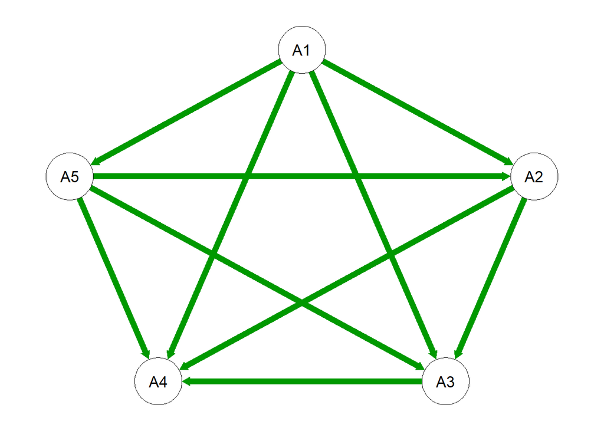

```r
qgraph::qgraph(tab.Pthee.i$tablarelacionsupera)
```

Observando en la salida los flujos de Entrada y Salida podemos ver que A1 y A5 son altamente preferidas por otras alternativas (flujos de entrada altos). Concretamente la mejor es A1 con mayor flujo de entrada y menor flujo de salida.

Si vemos las relaciones de Superación vemos como A1 supera consistentemente a las demás, A5 tiene un buen desempeño relativo y A4 no supera a ninguna alternativa. Luego la mejor alternativa según el promethee I es A1 (casa en el pueblo).

**Método Promethee II**

```r
tab.Pthee.ii <- multicriterio.metodo.promethee_ii(datos, pesos.criterios = tabla_pref[,3]/sum(tabla_pref[,3]),
tab.fpref = tabla_pref)
tab.Pthee.ii
```

```
## $tabla.indices
##           A1        A2        A3        A4        A5
## A1 0.0000000 0.1944444 0.3055556 0.7222222 0.5277778
## A2 0.1388889 0.0000000 0.4722222 0.7222222 0.3333333
## A3 0.3333333 0.3333333 0.0000000 0.5277778 0.2222222
## A4 0.1388889 0.1388889 0.1388889 0.0000000 0.0000000
## A5 0.3333333 0.5277778 0.3333333 0.5277778 0.0000000
##
## $vflujos.netos
##         A1         A2         A3         A4         A5
##  0.8055556  0.4722222  0.1666667 -2.0833333  0.6388889
##
## $tablarelacionsupera
##     A1  A2  A3  A4  A5
## A1 0.5 1.0 1.0 1.0 1.0
## A2 0.0 0.5 1.0 1.0 0.0
## A3 0.0 0.0 0.5 1.0 0.0
## A4 0.0 0.0 0.0 0.5 0.0
## A5 0.0 1.0 1.0 1.0 0.5
```

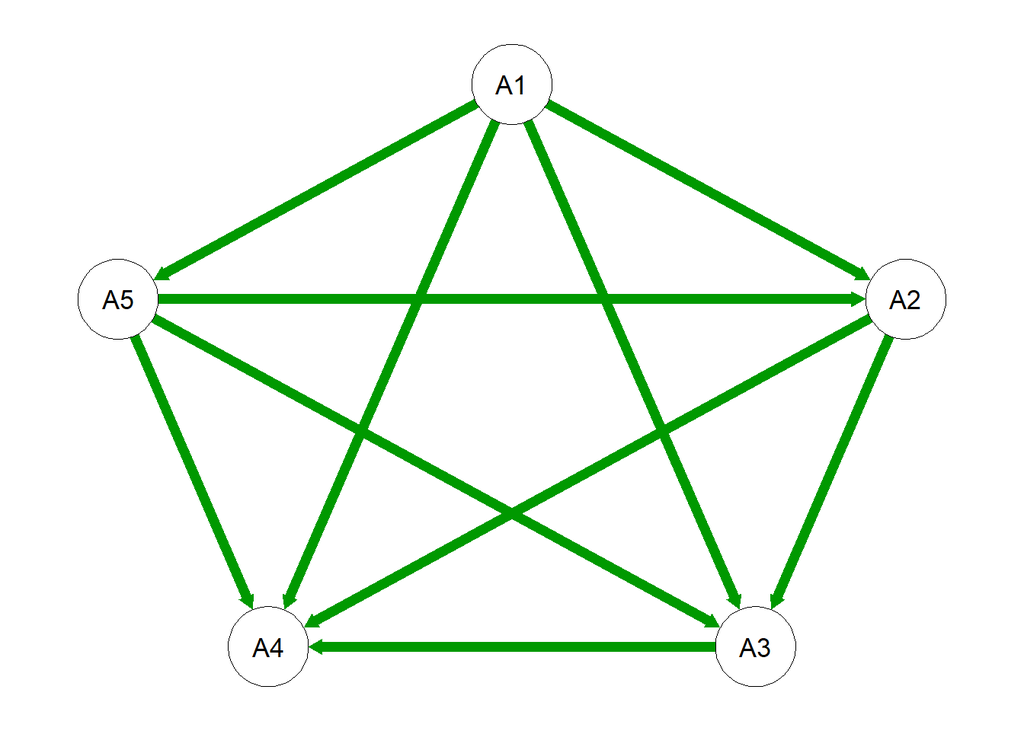

```r
qgraph::qgraph(tab.Pthee.ii$tablarelacionsupera)
```

Ordenación final alternativas del Método Promethee II:

```r
order(tab.Pthee.ii$vflujos.netos,decreasing = T)
```

```
## [1] 1 5 2 3 4
```

Con este método vemos que según la ordenación, A1 vuelve a ser la mejor alternativa, seguida de A5 mientras que A4 sigue siendo la peor alternativa. Sigue siendo la alternativa que supera consistentemente a las demás, luego A1 (casa en el pueblo) es la mejor para el promethee II.

**Metodo Promethee I medias**

```r
tab.Pthee.i_medias <- multicriterio.metodo.promethee_i_med(datos,
 pesos.criterios = tabla_pref[,3]/sum(tabla_pref[,3]),tab.fpref = tabla_pref)
tab.Pthee.i_medias
```

```
## $tabla.indices
##           A1        A2        A3        A4        A5
## A1 0.0000000 0.1944444 0.3055556 0.7222222 0.5277778
## A2 0.1388889 0.0000000 0.4722222 0.7222222 0.3333333
## A3 0.3333333 0.3333333 0.0000000 0.5277778 0.2222222
## A4 0.1388889 0.1388889 0.1388889 0.0000000 0.0000000
## A5 0.3333333 0.5277778 0.3333333 0.5277778 0.0000000
##
## $vflujos.ent
##        A1        A2        A3        A4        A5
## 0.4375000 0.4166667 0.3541667 0.1041667 0.4305556
##
## $vflujos.sal
##        A1        A2        A3        A4        A5
## 0.2361111 0.2986111 0.3125000 0.6250000 0.2708333
##
## $tablarelacionsupera
##    A1 A2 A3 A4 A5
## A1  0  1  1  1  1
## A2  0  0  1  1  0
## A3  0  0  0  1  0
## A4  0  0  0  0  0
## A5  0  1  1  1  0
```

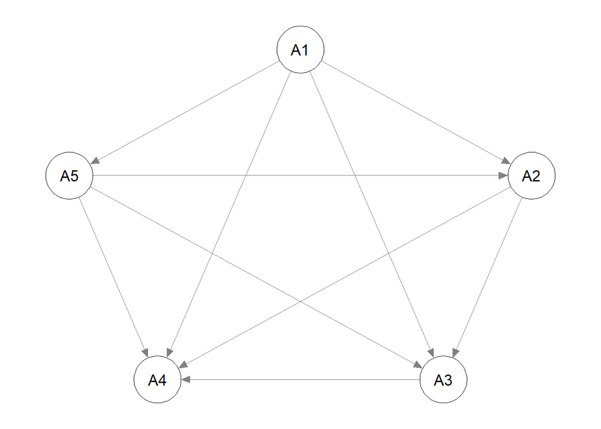

```r
qgraph::qgraph(tab.Pthee.i_medias$tablarelacionsupera)
```

Viendo los resultados vemos que A1 supera a todas las demás alternativas, mostrando su posición dominante. Vemos que A5 supera a A2, A3, y A4, siendo la segunda más fuerte mientras que A4 no supera a ninguna alternativa, colocándola en la última posición.

Luego la casa en el pueblo es la mejor alternativa según el método promethee I medias.

**Metodo Promethee II medias**

```r
tab.Pthee.ii_medias <- multicriterio.metodo.promethee_ii_med(datos,pesos.criterios = tabla_pref[,3]/sum(tabla_pref[,3]),tab.fpref = tabla_pref)
tab.Pthee.ii_medias
```

```
## $tabla.indices
##           A1        A2        A3        A4        A5
## A1 0.0000000 0.1944444 0.3055556 0.7222222 0.5277778
## A2 0.1388889 0.0000000 0.4722222 0.7222222 0.3333333
## A3 0.3333333 0.3333333 0.0000000 0.5277778 0.2222222
## A4 0.1388889 0.1388889 0.1388889 0.0000000 0.0000000
## A5 0.3333333 0.5277778 0.3333333 0.5277778 0.0000000
##
## $vflujos.netos
##          A1          A2          A3          A4          A5
##  0.20138889  0.11805556  0.04166667 -0.52083333  0.15972222
##
## $tablarelacionsupera
##    A1 A2 A3 A4 A5
## A1  0  1  1  1  1
## A2  0  0  1  1  0
## A3  0  0  0  1  0
## A4  0  0  0  0  0
## A5  0  1  1  1  0
```

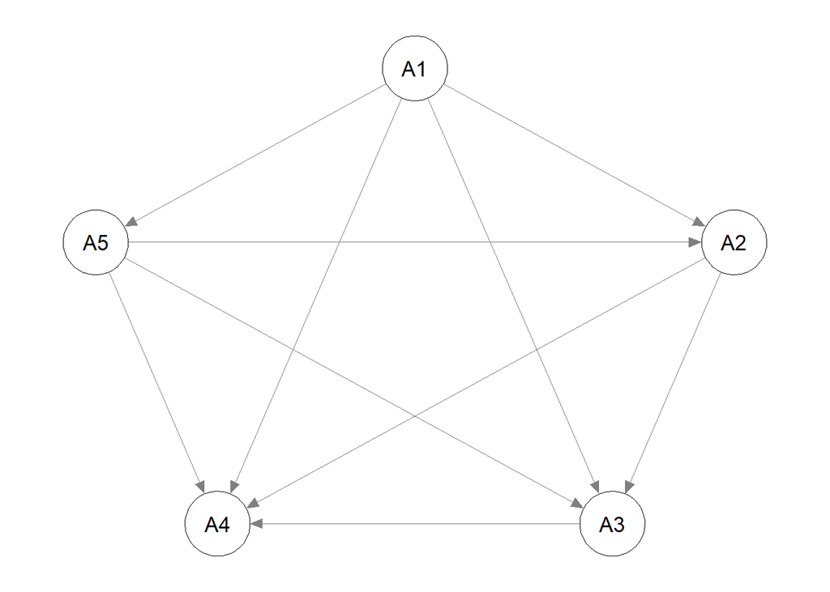

```r
qgraph::qgraph(tab.Pthee.ii_medias$tablarelacionsupera)
```

Ordenación final alternativas del Método Promethee II Medias:

```r
order(tab.Pthee.ii_medias$vflujos.netos,decreasing = T)
```

```
## [1] 1 5 2 3 4
```

#### **Método Electre**

Para poner en práctica este método, vamos a seguir utilizando la misma matriz de decisión que hemos utilizado en el método promethee.

```r
datos = multicriterio.crea.matrizdecision(c(9,-120, 70, 6,  9, 8,
                                           10,-250, 85, 7, 10, 9,
                                            8,-200, 125, 8, 7, 7,
                                            7,-300, 110, 4, 6, 9,
                                            6,-160, 140, 9, 7, 8),
                                    numalternativas = 5, numcriterios = 6,
                                    v.nombresalt = alternativas,
                                    v.nombrescri = criterios)
datos
```

```
##    Ubicacion Precio Tamaño Seguridad Servicios Estado
## A1         9   -120     70         6         9      8
## A2        10   -250     85         7        10      9
## A3         8   -200    125         8         7      7
## A4         7   -300    110         4         6      9
## A5         6   -160    140         9         7      8
```

```r
pesos.criterios = tabla_pref[,3]/sum(tabla_pref[,3])
```

Una vez aclarado los datos con los que vamos a trabajar, vamos ahora a aplicar el método electre para ver cuales serian las mejores alternativas:

```r
sal7 <- multicriterio.metodoELECTRE_I(datos,
                                      pesos.criterios = pesos.criterios,
                                      nivel.concordancia.minimo.alpha = 0.7,
                                      no.se.compensan = c(Inf, 100, Inf, Inf, Inf, Inf),
                                      que.alternativas = T)
sal7
```

```
## $datos
##                  Ubicacion       Precio      Tamaño Seguridad  Servicios
## A1               9.0000000 -120.0000000  70.0000000 6.0000000  9.0000000
## A2              10.0000000 -250.0000000  85.0000000 7.0000000 10.0000000
## A3               8.0000000 -200.0000000 125.0000000 8.0000000  7.0000000
## A4               7.0000000 -300.0000000 110.0000000 4.0000000  6.0000000
## A5               6.0000000 -160.0000000 140.0000000 9.0000000  7.0000000
## pesos.criterios  0.2222222    0.1944444   0.1388889 0.1944444  0.1111111
## no.se.compensan        Inf  100.0000000         Inf       Inf        Inf
##                    Estado
## A1              8.0000000
## A2              9.0000000
## A3              7.0000000
## A4              9.0000000
## A5              8.0000000
## pesos.criterios 0.1388889
## no.se.compensan       Inf
##
## $alpha
## [1] 0.7
##
## $Imas
## , , Ubicacion
##
##       A1    A2    A3    A4    A5
## A1 FALSE FALSE  TRUE  TRUE  TRUE
## A2  TRUE FALSE  TRUE  TRUE  TRUE
## A3 FALSE FALSE FALSE  TRUE  TRUE
## A4 FALSE FALSE FALSE FALSE  TRUE
## A5 FALSE FALSE FALSE FALSE FALSE
##
## , , Precio
##
##       A1    A2    A3    A4    A5
## A1 FALSE  TRUE  TRUE  TRUE  TRUE
## A2 FALSE FALSE FALSE  TRUE FALSE
## A3 FALSE  TRUE FALSE  TRUE FALSE
## A4 FALSE FALSE FALSE FALSE FALSE
## A5 FALSE  TRUE  TRUE  TRUE FALSE
##
```

[output cut: 177 more lines]

```
## A3  TRUE TRUE  TRUE TRUE  TRUE
## A4 FALSE TRUE FALSE TRUE FALSE
## A5  TRUE TRUE  TRUE TRUE  TRUE
##
## $relacion.dominante
##       A1    A2    A3    A4    A5
## A1 FALSE FALSE FALSE  TRUE FALSE
## A2 FALSE FALSE FALSE  TRUE FALSE
## A3 FALSE FALSE FALSE  TRUE FALSE
## A4 FALSE FALSE FALSE FALSE FALSE
## A5 FALSE FALSE  TRUE FALSE FALSE
##
## $nucleo_aprox
## A1 A2 A5
##  1  2  5
```

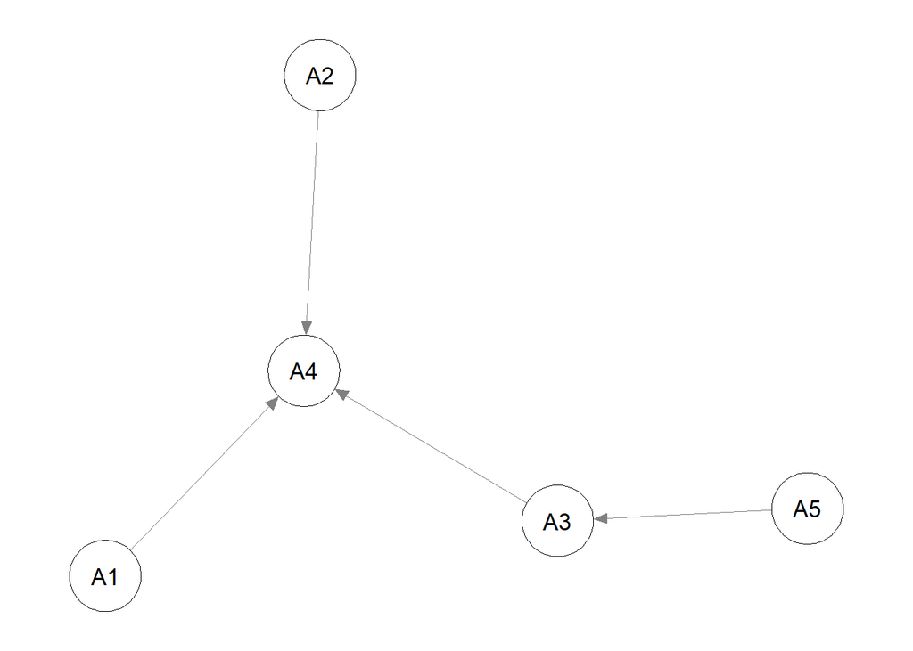

```r
qgraph::qgraph(sal7$relacion.dominante)
```

Vemos como A1, A2, y A5 forman parte del núcleo aproximado, lo que indica que son las alternativas más fuertes y preferidas según el análisis. Reducimos el alfha para sacar mejores conclusiones:

```r
sal7_reducida <- multicriterio.metodoELECTRE_I(datos,
                                      pesos.criterios = pesos.criterios,
                                      nivel.concordancia.minimo.alpha = 0.52,
                                     no.se.compensan = c(Inf,100,Inf,Inf,Inf, Inf),
                                      que.alternativas = c(1,2,5))
sal7_reducida
```

```
## $datos
##                  Ubicacion       Precio      Tamaño Seguridad  Servicios
## A1               9.0000000 -120.0000000  70.0000000 6.0000000  9.0000000
## A2              10.0000000 -250.0000000  85.0000000 7.0000000 10.0000000
## A5               6.0000000 -160.0000000 140.0000000 9.0000000  7.0000000
## pesos.criterios  0.2222222    0.1944444   0.1388889 0.1944444  0.1111111
## no.se.compensan        Inf  100.0000000         Inf       Inf        Inf
##                    Estado
## A1              8.0000000
## A2              9.0000000
## A5              8.0000000
## pesos.criterios 0.1388889
## no.se.compensan       Inf
##
## $alpha
## [1] 0.52
##
## $Imas
## , , Ubicacion
##
##       A1    A2    A5
## A1 FALSE FALSE  TRUE
## A2  TRUE FALSE  TRUE
## A5 FALSE FALSE FALSE
##
## , , Precio
##
##       A1    A2    A5
## A1 FALSE  TRUE  TRUE
## A2 FALSE FALSE FALSE
## A5 FALSE  TRUE FALSE
##
## , , Tamaño
##
##       A1    A2    A5
## A1 FALSE FALSE FALSE
## A2  TRUE FALSE FALSE
## A5  TRUE  TRUE FALSE
##
## , , Seguridad
```

[output cut: 127 more lines]

```
## $test.discordancia
##       A1   A2   A5
## A1  TRUE TRUE TRUE
## A2 FALSE TRUE TRUE
## A5  TRUE TRUE TRUE
##
## $relacion.dominante
##       A1    A2    A5
## A1 FALSE FALSE  TRUE
## A2 FALSE FALSE FALSE
## A5 FALSE  TRUE FALSE
##
## $nucleo_aprox
## A1
##  1
```

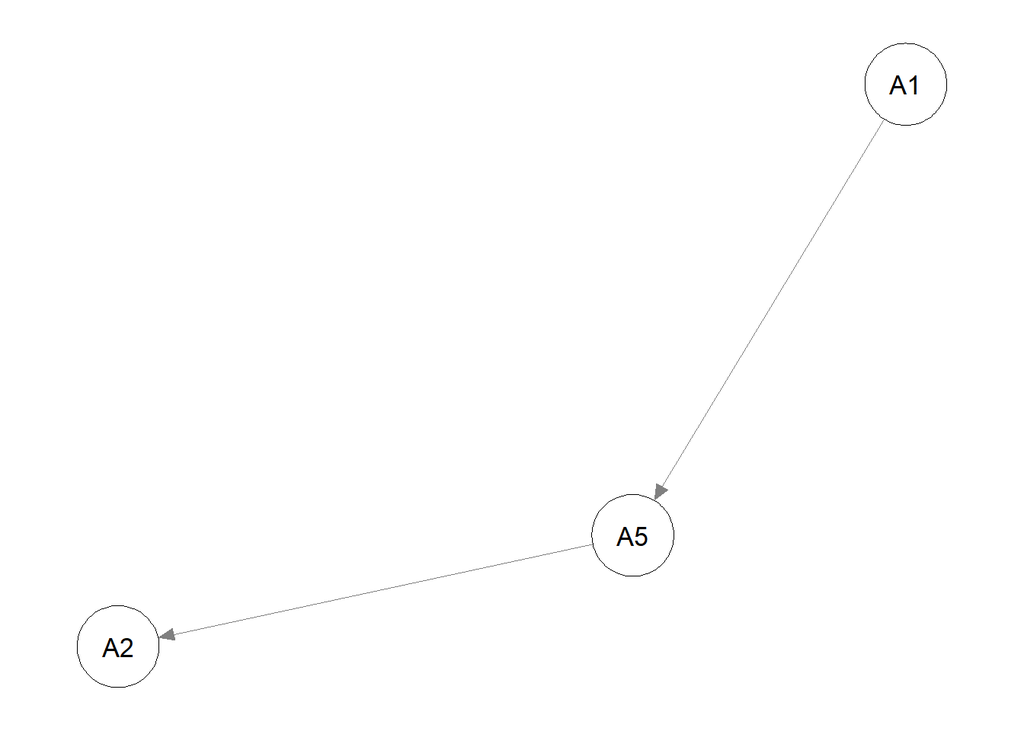

```r
qgraph::qgraph(sal7_reducida$relacion.dominante)
```

#### **Método AHP**

Relación entre criterios:

```r
criterio_df <- multicriterio.crea.matrizvaloraciones_mej(c(2,3,2,4,3,
                                                     3,1,4,3,
                                                     1/3,2,1,
                                                     4,3,
                                                     1/2),
                                                   numalternativas = 6,
                                                   v.nombres.alternativas = criterios)
kable(criterio_df)
```

|  | Ubicacion | Precio | Tamaño | Seguridad | Servicios | Estado |
| --- | --- | --- | --- | --- | --- | --- |
| Ubicacion | 1.0000000 | 2.0000000 | 3.0 | 2.0000000 | 4 | 3.0 |
| Precio | 0.5000000 | 1.0000000 | 3.0 | 1.0000000 | 4 | 3.0 |
| Tamaño | 0.3333333 | 0.3333333 | 1.0 | 0.3333333 | 2 | 1.0 |
| Seguridad | 0.5000000 | 1.0000000 | 3.0 | 1.0000000 | 4 | 3.0 |
| Servicios | 0.2500000 | 0.2500000 | 0.5 | 0.2500000 | 1 | 0.5 |
| Estado | 0.3333333 | 0.3333333 | 1.0 | 0.3333333 | 2 | 1.0 |

Criterios dos a dos:

```r
ubicacion_2 <- multicriterio.crea.matrizvaloraciones_mej(
  c(1/2,2,3,4,3,4,5,2,3,2),
  numalternativas = 5,
  v.nombres.alternativas = alternativas)
#Ubicacion:
ubicacion_2
```

```
##           A1        A2        A3  A4 A5
## A1 1.0000000 0.5000000 2.0000000 3.0  4
## A2 2.0000000 1.0000000 3.0000000 4.0  5
## A3 0.5000000 0.3333333 1.0000000 2.0  3
## A4 0.3333333 0.2500000 0.5000000 1.0  2
## A5 0.2500000 0.2000000 0.3333333 0.5  1
```

```r
precio_2 <- multicriterio.crea.matrizvaloraciones_mej(
  c(4,3,5,2,1/3,3,1/2,2,1/2,1/5),
  numalternativas = 5,
  v.nombres.alternativas = alternativas)
#Precio
precio_2
```

```
##           A1        A2        A3 A4  A5
## A1 1.0000000 4.0000000 3.0000000  5 2.0
## A2 0.2500000 1.0000000 0.3333333  3 0.5
## A3 0.3333333 3.0000000 1.0000000  2 0.5
## A4 0.2000000 0.3333333 0.5000000  1 0.2
## A5 0.5000000 2.0000000 2.0000000  5 1.0
```

```r
tamaño_2 <- multicriterio.crea.matrizvaloraciones_mej(
  c(1/2,1/4,1/3,1/5,1/3,1/2,1/4,3,1/2,1/3),
  numalternativas = 5,
  v.nombres.alternativas = alternativas)
#Tamaño e infraestucturas
tamaño_2
```

```
##    A1  A2        A3        A4        A5
## A1  1 0.5 0.2500000 0.3333333 0.2000000
## A2  2 1.0 0.3333333 0.5000000 0.2500000
## A3  4 3.0 1.0000000 3.0000000 0.5000000
## A4  3 2.0 0.3333333 1.0000000 0.3333333
## A5  5 4.0 2.0000000 3.0000000 1.0000000
```

```r
seguridad_2 <- multicriterio.crea.matrizvaloraciones_mej(
  c(1/2,1/3,3,1/4,1/2,4,1/3,5,1/2,1/5),
  numalternativas = 5,
  v.nombres.alternativas = alternativas)
#Seguridad
seguridad_2
```

```
##           A1   A2        A3 A4        A5
## A1 1.0000000 0.50 0.3333333  3 0.2500000
## A2 2.0000000 1.00 0.5000000  4 0.3333333
## A3 3.0000000 2.00 1.0000000  5 0.5000000
## A4 0.3333333 0.25 0.2000000  1 0.2000000
## A5 4.0000000 3.00 2.0000000  5 1.0000000
```

```r
servicios_2 <- multicriterio.crea.matrizvaloraciones_mej(
  c(1/2,3,2,3,3,2,3,2,1,1/2),
  numalternativas = 5,
  v.nombres.alternativas = alternativas)
#Servicios
servicios_2
```

```
##           A1        A2  A3 A4  A5
## A1 1.0000000 0.5000000 3.0  2 3.0
## A2 2.0000000 1.0000000 3.0  2 3.0
## A3 0.3333333 0.3333333 1.0  2 1.0
## A4 0.5000000 0.5000000 0.5  1 0.5
## A5 0.3333333 0.3333333 1.0  2 1.0
```

```r
estado_2 <- multicriterio.crea.matrizvaloraciones_mej(
  c(1/2,2,1/2,1,3,1,2,1/3,1/2,2),
  numalternativas = 5,
  v.nombres.alternativas = alternativas)
#Estados
estado_2
```

```
##     A1        A2 A3        A4  A5
## A1 1.0 0.5000000  2 0.5000000 1.0
## A2 2.0 1.0000000  3 1.0000000 2.0
## A3 0.5 0.3333333  1 0.3333333 0.5
## A4 2.0 1.0000000  3 1.0000000 2.0
## A5 1.0 0.5000000  2 0.5000000 1.0
```

Una vez definido las matrices de comparaciones de criterios y los criterios a pares dos a dos, aplicamos este método:

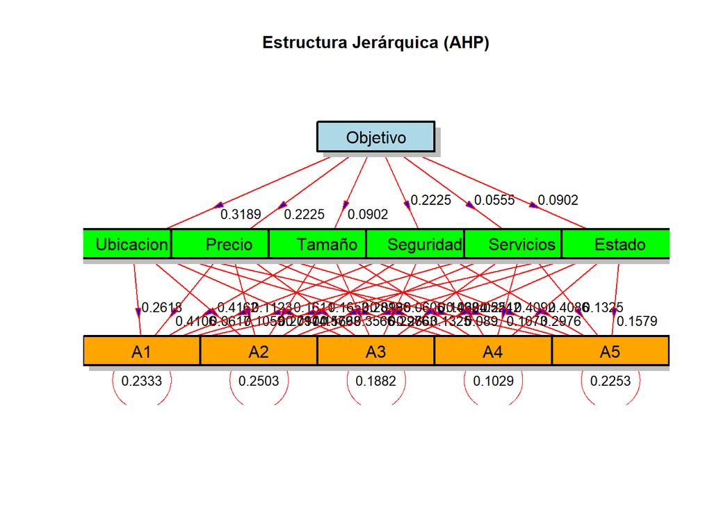

```r
### Identificar el diagrama de jerarquias de este problema de decisión

xmatn01 <- criterio_df
xmatn02 <- array(NA,dim = c(5,5,6))
xmatn02[,,1] <- ubicacion_2
xmatn02[,,2] <- precio_2
xmatn02[,,3] <- tamaño_2
xmatn02[,,4] <- seguridad_2
xmatn02[,,5] <- servicios_2
xmatn02[,,6] <- estado_2
dimnames(xmatn02)[[1]] <- alternativas
dimnames(xmatn02)[[2]] <- alternativas
dimnames(xmatn02)[[3]] <- criterios
multicriterio.metodoahp.diagrama(xmatn01,xmatn02)
```

Según este diagrama de jerarquías que hemos construidos a partir de las matrices de comparaciones a pares podemos observar como la mejor alternativa es A2 (casa en la ciudad), con un peso global del 25,03%. Sin embargo, la peor es A4 (casa en la playa) con un peso global del 10,29%.

Ponderaciones asociadas a cada criterio manejado:

```r
#Pesos locales de la Matriz de Criterios
p106 <- multicriterio.metodoAHP.variante3.basico(criterio_df)
p106
```

```
## $Xmat
##           Ubicacion    Precio Tamaño Seguridad Servicios Estado
## Ubicacion 1.0000000 2.0000000    3.0 2.0000000         4    3.0
## Precio    0.5000000 1.0000000    3.0 1.0000000         4    3.0
## Tamaño    0.3333333 0.3333333    1.0 0.3333333         2    1.0
## Seguridad 0.5000000 1.0000000    3.0 1.0000000         4    3.0
## Servicios 0.2500000 0.2500000    0.5 0.2500000         1    0.5
## Estado    0.3333333 0.3333333    1.0 0.3333333         2    1.0
##
## $sumacolumnas
## Ubicacion    Precio    Tamaño Seguridad Servicios    Estado
##  2.916667  4.916667 11.500000  4.916667 17.000000 11.500000
##
## $Xmat.normalizada
##            Ubicacion     Precio     Tamaño  Seguridad  Servicios     Estado
## Ubicacion 0.34285714 0.40677966 0.26086957 0.40677966 0.23529412 0.26086957
## Precio    0.17142857 0.20338983 0.26086957 0.20338983 0.23529412 0.26086957
## Tamaño    0.11428571 0.06779661 0.08695652 0.06779661 0.11764706 0.08695652
## Seguridad 0.17142857 0.20338983 0.26086957 0.20338983 0.23529412 0.26086957
## Servicios 0.08571429 0.05084746 0.04347826 0.05084746 0.05882353 0.04347826
## Estado    0.11428571 0.06779661 0.08695652 0.06779661 0.11764706 0.08695652
##
## $valoraciones.ahp
##  Ubicacion     Precio     Tamaño  Seguridad  Servicios     Estado
## 0.31890829 0.22254025 0.09023984 0.22254025 0.05553154 0.09023984
##
## $valoraciones.ahp.ordenadas
##  Ubicacion     Precio  Seguridad     Tamaño     Estado  Servicios
## 0.31890829 0.22254025 0.22254025 0.09023984 0.09023984 0.05553154
##
## $tablaresumen
##           Ubicacion    Precio Tamaño Seguridad Servicios Estado  Ubicacion
## Ubicacion 1.0000000 2.0000000    3.0 2.0000000         4    3.0 0.34285714
## Precio    0.5000000 1.0000000    3.0 1.0000000         4    3.0 0.17142857
## Tamaño    0.3333333 0.3333333    1.0 0.3333333         2    1.0 0.11428571
## Seguridad 0.5000000 1.0000000    3.0 1.0000000         4    3.0 0.17142857
## Servicios 0.2500000 0.2500000    0.5 0.2500000         1    0.5 0.08571429
## Estado    0.3333333 0.3333333    1.0 0.3333333         2    1.0 0.11428571
##           2.9166667 4.9166667   11.5 4.9166667        17   11.5         NA
##               Precio     Tamaño  Seguridad  Servicios     Estado
## Ubicacion 0.40677966 0.26086957 0.40677966 0.23529412 0.26086957
## Precio    0.20338983 0.26086957 0.20338983 0.23529412 0.26086957
## Tamaño    0.06779661 0.08695652 0.06779661 0.11764706 0.08695652
## Seguridad 0.20338983 0.26086957 0.20338983 0.23529412 0.26086957
## Servicios 0.05084746 0.04347826 0.05084746 0.05882353 0.04347826
## Estado    0.06779661 0.08695652 0.06779661 0.11764706 0.08695652
##                   NA         NA         NA         NA         NA
##           prioridades.relativas
## Ubicacion            0.31890829
## Precio               0.22254025
## Tamaño               0.09023984
## Seguridad            0.22254025
## Servicios            0.05553154
## Estado               0.09023984
##                              NA
```

Podemos observar que la Ubicación es el criterio más influyente en la toma de decisiones, seguido del precio. Seguramente por la situación económica en la que se encuentre la familia. El criterio del que menos se ha tenido en cuenta son los servicios de la vivienda.

Ponderaciones de las alternativas en función de cada criterio.

```r
p106_ubicacion <-  multicriterio.metodoAHP.variante3.basico(ubicacion_2)
p106_ubicacion
```

```
## $Xmat
##           A1        A2        A3  A4 A5
## A1 1.0000000 0.5000000 2.0000000 3.0  4
## A2 2.0000000 1.0000000 3.0000000 4.0  5
## A3 0.5000000 0.3333333 1.0000000 2.0  3
## A4 0.3333333 0.2500000 0.5000000 1.0  2
## A5 0.2500000 0.2000000 0.3333333 0.5  1
##
## $sumacolumnas
##        A1        A2        A3        A4        A5
##  4.083333  2.283333  6.833333 10.500000 15.000000
##
## $Xmat.normalizada
##            A1         A2         A3         A4         A5
## A1 0.24489796 0.21897810 0.29268293 0.28571429 0.26666667
## A2 0.48979592 0.43795620 0.43902439 0.38095238 0.33333333
## A3 0.12244898 0.14598540 0.14634146 0.19047619 0.20000000
## A4 0.08163265 0.10948905 0.07317073 0.09523810 0.13333333
## A5 0.06122449 0.08759124 0.04878049 0.04761905 0.06666667
##
## $valoraciones.ahp
##         A1         A2         A3         A4         A5
## 0.26178799 0.41621245 0.16105041 0.09857277 0.06237639
##
## $valoraciones.ahp.ordenadas
##         A2         A1         A3         A4         A5
## 0.41621245 0.26178799 0.16105041 0.09857277 0.06237639
##
## $tablaresumen
##           A1        A2        A3   A4 A5         A1         A2         A3
## A1 1.0000000 0.5000000 2.0000000  3.0  4 0.24489796 0.21897810 0.29268293
## A2 2.0000000 1.0000000 3.0000000  4.0  5 0.48979592 0.43795620 0.43902439
## A3 0.5000000 0.3333333 1.0000000  2.0  3 0.12244898 0.14598540 0.14634146
## A4 0.3333333 0.2500000 0.5000000  1.0  2 0.08163265 0.10948905 0.07317073
## A5 0.2500000 0.2000000 0.3333333  0.5  1 0.06122449 0.08759124 0.04878049
##    4.0833333 2.2833333 6.8333333 10.5 15         NA         NA         NA
##            A4         A5 prioridades.relativas
## A1 0.28571429 0.26666667            0.26178799
## A2 0.38095238 0.33333333            0.41621245
## A3 0.19047619 0.20000000            0.16105041
## A4 0.09523810 0.13333333            0.09857277
## A5 0.04761905 0.06666667            0.06237639
##            NA         NA                    NA
```

Si solo tenemos en cuenta la ubicación como criterio de elección de una vivienda, obtendríamos los siguientes resultados: A2 > A1 > A3 > A4 > A5. Vemos como la casa en la ciudad, que corresponde con A2, es la que mejor ubicación tiene.

```r
p106_precio <-  multicriterio.metodoAHP.variante3.basico(precio_2)
p106_precio
```

```
## $Xmat
##           A1        A2        A3 A4  A5
## A1 1.0000000 4.0000000 3.0000000  5 2.0
## A2 0.2500000 1.0000000 0.3333333  3 0.5
## A3 0.3333333 3.0000000 1.0000000  2 0.5
## A4 0.2000000 0.3333333 0.5000000  1 0.2
## A5 0.5000000 2.0000000 2.0000000  5 1.0
##
## $sumacolumnas
##        A1        A2        A3        A4        A5
##  2.283333 10.333333  6.833333 16.000000  4.200000
##
## $Xmat.normalizada
##            A1         A2         A3     A4         A5
## A1 0.43795620 0.38709677 0.43902439 0.3125 0.47619048
## A2 0.10948905 0.09677419 0.04878049 0.1875 0.11904762
## A3 0.14598540 0.29032258 0.14634146 0.1250 0.11904762
## A4 0.08759124 0.03225806 0.07317073 0.0625 0.04761905
## A5 0.21897810 0.19354839 0.29268293 0.3125 0.23809524
##
## $valoraciones.ahp
##         A1         A2         A3         A4         A5
## 0.41055357 0.11231827 0.16533941 0.06062782 0.25116093
##
## $valoraciones.ahp.ordenadas
##         A1         A5         A3         A2         A4
## 0.41055357 0.25116093 0.16533941 0.11231827 0.06062782
##
## $tablaresumen
##           A1         A2        A3 A4  A5         A1         A2         A3
## A1 1.0000000  4.0000000 3.0000000  5 2.0 0.43795620 0.38709677 0.43902439
## A2 0.2500000  1.0000000 0.3333333  3 0.5 0.10948905 0.09677419 0.04878049
## A3 0.3333333  3.0000000 1.0000000  2 0.5 0.14598540 0.29032258 0.14634146
## A4 0.2000000  0.3333333 0.5000000  1 0.2 0.08759124 0.03225806 0.07317073
## A5 0.5000000  2.0000000 2.0000000  5 1.0 0.21897810 0.19354839 0.29268293
##    2.2833333 10.3333333 6.8333333 16 4.2         NA         NA         NA
##        A4         A5 prioridades.relativas
## A1 0.3125 0.47619048            0.41055357
## A2 0.1875 0.11904762            0.11231827
## A3 0.1250 0.11904762            0.16533941
## A4 0.0625 0.04761905            0.06062782
## A5 0.3125 0.23809524            0.25116093
##        NA         NA                    NA
```

Si solo tenemos en cuenta el precio como criterio de elección de una vivienda, obtendríamos los siguientes resultados: A1 > A5 > A3 > A2 > A4. Vemos como A1 esa la mejor segun solo este criterio, puesto que es la más barata de todas las opciones.

```r
p106_tamaño <-  multicriterio.metodoAHP.variante3.basico(tamaño_2)
p106_tamaño
```

```
## $Xmat
##    A1  A2        A3        A4        A5
## A1  1 0.5 0.2500000 0.3333333 0.2000000
## A2  2 1.0 0.3333333 0.5000000 0.2500000
## A3  4 3.0 1.0000000 3.0000000 0.5000000
## A4  3 2.0 0.3333333 1.0000000 0.3333333
## A5  5 4.0 2.0000000 3.0000000 1.0000000
##
## $sumacolumnas
##        A1        A2        A3        A4        A5
## 15.000000 10.500000  3.916667  7.833333  2.283333
##
## $Xmat.normalizada
##            A1         A2         A3         A4         A5
## A1 0.06666667 0.04761905 0.06382979 0.04255319 0.08759124
## A2 0.13333333 0.09523810 0.08510638 0.06382979 0.10948905
## A3 0.26666667 0.28571429 0.25531915 0.38297872 0.21897810
## A4 0.20000000 0.19047619 0.08510638 0.12765957 0.14598540
## A5 0.33333333 0.38095238 0.51063830 0.38297872 0.43795620
##
## $valoraciones.ahp
##         A1         A2         A3         A4         A5
## 0.06165199 0.09739933 0.28193139 0.14984551 0.40917179
##
## $valoraciones.ahp.ordenadas
##         A5         A3         A4         A2         A1
## 0.40917179 0.28193139 0.14984551 0.09739933 0.06165199
##
## $tablaresumen
##    A1   A2        A3        A4        A5         A1         A2         A3
## A1  1  0.5 0.2500000 0.3333333 0.2000000 0.06666667 0.04761905 0.06382979
## A2  2  1.0 0.3333333 0.5000000 0.2500000 0.13333333 0.09523810 0.08510638
## A3  4  3.0 1.0000000 3.0000000 0.5000000 0.26666667 0.28571429 0.25531915
## A4  3  2.0 0.3333333 1.0000000 0.3333333 0.20000000 0.19047619 0.08510638
## A5  5  4.0 2.0000000 3.0000000 1.0000000 0.33333333 0.38095238 0.51063830
##    15 10.5 3.9166667 7.8333333 2.2833333         NA         NA         NA
##            A4         A5 prioridades.relativas
## A1 0.04255319 0.08759124            0.06165199
## A2 0.06382979 0.10948905            0.09739933
## A3 0.38297872 0.21897810            0.28193139
## A4 0.12765957 0.14598540            0.14984551
## A5 0.38297872 0.43795620            0.40917179
##            NA         NA                    NA
```

Si solo tenemos en cuenta el tamaño como criterio de elección de una vivienda, obtendríamos los siguientes resultados: A5 > A3 > A4 > A2 > A1. Vemos A5 (casa en el campo) es la de mayor tamaño con respecto al resto.

```r
p106_seguridad <-  multicriterio.metodoAHP.variante3.basico(seguridad_2)
p106_seguridad
```

```
## $Xmat
##           A1   A2        A3 A4        A5
## A1 1.0000000 0.50 0.3333333  3 0.2500000
## A2 2.0000000 1.00 0.5000000  4 0.3333333
## A3 3.0000000 2.00 1.0000000  5 0.5000000
## A4 0.3333333 0.25 0.2000000  1 0.2000000
## A5 4.0000000 3.00 2.0000000  5 1.0000000
##
## $sumacolumnas
##        A1        A2        A3        A4        A5
## 10.333333  6.750000  4.033333 18.000000  2.283333
##
## $Xmat.normalizada
##            A1         A2         A3         A4         A5
## A1 0.09677419 0.07407407 0.08264463 0.16666667 0.10948905
## A2 0.19354839 0.14814815 0.12396694 0.22222222 0.14598540
## A3 0.29032258 0.29629630 0.24793388 0.27777778 0.21897810
## A4 0.03225806 0.03703704 0.04958678 0.05555556 0.08759124
## A5 0.38709677 0.44444444 0.49586777 0.27777778 0.43795620
##
## $valoraciones.ahp
##         A1         A2         A3         A4         A5
## 0.10592972 0.16677422 0.26626173 0.05240573 0.40862859
##
## $valoraciones.ahp.ordenadas
##         A5         A3         A2         A1         A4
## 0.40862859 0.26626173 0.16677422 0.10592972 0.05240573
##
## $tablaresumen
##            A1   A2        A3 A4        A5         A1         A2         A3
## A1  1.0000000 0.50 0.3333333  3 0.2500000 0.09677419 0.07407407 0.08264463
## A2  2.0000000 1.00 0.5000000  4 0.3333333 0.19354839 0.14814815 0.12396694
## A3  3.0000000 2.00 1.0000000  5 0.5000000 0.29032258 0.29629630 0.24793388
## A4  0.3333333 0.25 0.2000000  1 0.2000000 0.03225806 0.03703704 0.04958678
## A5  4.0000000 3.00 2.0000000  5 1.0000000 0.38709677 0.44444444 0.49586777
##    10.3333333 6.75 4.0333333 18 2.2833333         NA         NA         NA
##            A4         A5 prioridades.relativas
## A1 0.16666667 0.10948905            0.10592972
## A2 0.22222222 0.14598540            0.16677422
## A3 0.27777778 0.21897810            0.26626173
## A4 0.05555556 0.08759124            0.05240573
## A5 0.27777778 0.43795620            0.40862859
##            NA         NA                    NA
```

Si solo tenemos en cuenta la seguridad como criterio de elección de una vivienda, obtendríamos los siguientes resultados: A5 > A3 > A2 > A1 > A4. Esta alternativa A5 (casa en el campo) es la más segura de todas las opciones.

```r
p106_servicios <-  multicriterio.metodoAHP.variante3.basico(servicios_2)
p106_servicios
```

```
## $Xmat
##           A1        A2  A3 A4  A5
## A1 1.0000000 0.5000000 3.0  2 3.0
## A2 2.0000000 1.0000000 3.0  2 3.0
## A3 0.3333333 0.3333333 1.0  2 1.0
## A4 0.5000000 0.5000000 0.5  1 0.5
## A5 0.3333333 0.3333333 1.0  2 1.0
##
## $sumacolumnas
##       A1       A2       A3       A4       A5
## 4.166667 2.666667 8.500000 9.000000 8.500000
##
## $Xmat.normalizada
##      A1     A2         A3        A4         A5
## A1 0.24 0.1875 0.35294118 0.2222222 0.35294118
## A2 0.48 0.3750 0.35294118 0.2222222 0.35294118
## A3 0.08 0.1250 0.11764706 0.2222222 0.11764706
## A4 0.12 0.1875 0.05882353 0.1111111 0.05882353
## A5 0.08 0.1250 0.11764706 0.2222222 0.11764706
##
## $valoraciones.ahp
##        A1        A2        A3        A4        A5
## 0.2711209 0.3566209 0.1325033 0.1072516 0.1325033
##
## $valoraciones.ahp.ordenadas
##        A2        A1        A3        A5        A4
## 0.3566209 0.2711209 0.1325033 0.1325033 0.1072516
##
## $tablaresumen
##           A1        A2  A3 A4  A5   A1     A2         A3        A4         A5
## A1 1.0000000 0.5000000 3.0  2 3.0 0.24 0.1875 0.35294118 0.2222222 0.35294118
## A2 2.0000000 1.0000000 3.0  2 3.0 0.48 0.3750 0.35294118 0.2222222 0.35294118
## A3 0.3333333 0.3333333 1.0  2 1.0 0.08 0.1250 0.11764706 0.2222222 0.11764706
## A4 0.5000000 0.5000000 0.5  1 0.5 0.12 0.1875 0.05882353 0.1111111 0.05882353
## A5 0.3333333 0.3333333 1.0  2 1.0 0.08 0.1250 0.11764706 0.2222222 0.11764706
##    4.1666667 2.6666667 8.5  9 8.5   NA     NA         NA        NA         NA
##    prioridades.relativas
## A1             0.2711209
## A2             0.3566209
## A3             0.1325033
## A4             0.1072516
## A5             0.1325033
##                       NA
```

Si solo tenemos en cuenta la infraestuctura y los servicios como criterio de elección de una vivienda, obtendríamos los siguientes resultados: A2 > A1 > A3 > A5 > A4

```r
p106_estado <-  multicriterio.metodoAHP.variante3.basico(estado_2)
p106_estado
```

```
## $Xmat
##     A1        A2 A3        A4  A5
## A1 1.0 0.5000000  2 0.5000000 1.0
## A2 2.0 1.0000000  3 1.0000000 2.0
## A3 0.5 0.3333333  1 0.3333333 0.5
## A4 2.0 1.0000000  3 1.0000000 2.0
## A5 1.0 0.5000000  2 0.5000000 1.0
##
## $sumacolumnas
##        A1        A2        A3        A4        A5
##  6.500000  3.333333 11.000000  3.333333  6.500000
##
## $Xmat.normalizada
##            A1   A2         A3   A4         A5
## A1 0.15384615 0.15 0.18181818 0.15 0.15384615
## A2 0.30769231 0.30 0.27272727 0.30 0.30769231
## A3 0.07692308 0.10 0.09090909 0.10 0.07692308
## A4 0.30769231 0.30 0.27272727 0.30 0.30769231
## A5 0.15384615 0.15 0.18181818 0.15 0.15384615
##
## $valoraciones.ahp
##         A1         A2         A3         A4         A5
## 0.15790210 0.29762238 0.08895105 0.29762238 0.15790210
##
## $valoraciones.ahp.ordenadas
##         A2         A4         A1         A5         A3
## 0.29762238 0.29762238 0.15790210 0.15790210 0.08895105
##
## $tablaresumen
##     A1        A2 A3        A4  A5         A1   A2         A3   A4         A5
## A1 1.0 0.5000000  2 0.5000000 1.0 0.15384615 0.15 0.18181818 0.15 0.15384615
## A2 2.0 1.0000000  3 1.0000000 2.0 0.30769231 0.30 0.27272727 0.30 0.30769231
## A3 0.5 0.3333333  1 0.3333333 0.5 0.07692308 0.10 0.09090909 0.10 0.07692308
## A4 2.0 1.0000000  3 1.0000000 2.0 0.30769231 0.30 0.27272727 0.30 0.30769231
## A5 1.0 0.5000000  2 0.5000000 1.0 0.15384615 0.15 0.18181818 0.15 0.15384615
##    6.5 3.3333333 11 3.3333333 6.5         NA   NA         NA   NA         NA
##    prioridades.relativas
## A1            0.15790210
## A2            0.29762238
## A3            0.08895105
## A4            0.29762238
## A5            0.15790210
##                       NA
```

Si solo tenemos en cuenta el estado de una vivienda como criterio de elección de una vivienda, obtendríamos los siguientes resultados: A2 > A4 > A1 > A5 > A3. La casa en la ciudad, A2, es la que se encuentra en mejores condiciones.

Consistencia de las preferencias del centro decisor.

```r
multicriterio.metodoAHP.coef.inconsistencia(criterio_df)
```

```
## $lambda
## [1] 6.108656
##
## $m
## [1] 6
##
## $CI.coef.inconsistencia
## [1] 0.02173117
##
## $CA.aleatorio
## [1] 1.24
##
## $RI.coef.inconsistencia
## [1] 0.01752514
##
## $mensaje
## [1] "Consistencia aceptable"
```

La consistencia es aceptable. Por tanto, las preferencias expresadas en la matriz de comparación de criterios son razonablemente consistentes.

Consistencia por criterios:

```r
multicriterio.metodoAHP.coef.inconsistencia(ubicacion_2)
```

```
## $lambda
## [1] 5.06808
##
## $m
## [1] 5
##
## $CI.coef.inconsistencia
## [1] 0.01702006
##
## $CA.aleatorio
## [1] 1.12
##
## $RI.coef.inconsistencia
## [1] 0.01519649
##
## $mensaje
## [1] "Consistencia aceptable"
```

```r
# Ubicacion: Consistencia aceptable
```

```r
multicriterio.metodoAHP.coef.inconsistencia(precio_2)
```

```
## $lambda
## [1] 5.231048
##
## $m
## [1] 5
##
## $CI.coef.inconsistencia
## [1] 0.05776201
##
## $CA.aleatorio
## [1] 1.12
##
## $RI.coef.inconsistencia
## [1] 0.05157323
##
## $mensaje
## [1] "Consistencia aceptable"
```

```r
# Precio: Consistencia aceptable
```

```r
multicriterio.metodoAHP.coef.inconsistencia(tamaño_2)
```

```
## $lambda
## [1] 5.12064
##
## $m
## [1] 5
##
## $CI.coef.inconsistencia
## [1] 0.03015997
##
## $CA.aleatorio
## [1] 1.12
##
## $RI.coef.inconsistencia
## [1] 0.02692855
##
## $mensaje
## [1] "Consistencia aceptable"
```

```r
# Tamaño: Consistencia aceptable
```

```r
multicriterio.metodoAHP.coef.inconsistencia(seguridad_2)
```

```
## $lambda
## [1] 5.131598
##
## $m
## [1] 5
##
## $CI.coef.inconsistencia
## [1] 0.03289938
##
## $CA.aleatorio
## [1] 1.12
##
## $RI.coef.inconsistencia
## [1] 0.02937444
##
## $mensaje
## [1] "Consistencia aceptable"
```

```r
# Seguridad: Consistencia aceptable
```

```r
multicriterio.metodoAHP.coef.inconsistencia(servicios_2)
```

```
## $lambda
## [1] 5.25649
##
## $m
## [1] 5
##
## $CI.coef.inconsistencia
## [1] 0.06412244
##
## $CA.aleatorio
## [1] 1.12
##
## $RI.coef.inconsistencia
## [1] 0.05725218
##
## $mensaje
## [1] "Consistencia aceptable"
```

```r
# Servicios: Consistencia aceptable
```

```r
multicriterio.metodoAHP.coef.inconsistencia(estado_2)
```

```
## $lambda
## [1] 5.013263
##
## $m
## [1] 5
##
## $CI.coef.inconsistencia
## [1] 0.00331572
##
## $CA.aleatorio
## [1] 1.12
##
## $RI.coef.inconsistencia
## [1] 0.002960464
##
## $mensaje
## [1] "Consistencia aceptable"
```

```r
# Estado: Consistencia aceptable
```

Prioridad global

```r
 multicriterio.metodoAHP.pesosglobales_entabla(p106$valoraciones.ahp,
                                                    rbind(p106_ubicacion$valoraciones.ahp,
                                                          p106_precio$valoraciones.ahp,
                                                          p106_tamaño$valoraciones.ahp,
                                                          p106_seguridad$valoraciones.ahp,
                                                          p106_servicios$valoraciones.ahp,
                                                          p106_estado$valoraciones.ahp
                                                          ))
```

```
##                   Ubicacion     Precio     Tamaño  Seguridad  Servicios
## A1               0.26178799 0.41055357 0.06165199 0.10592972 0.27112092
## A2               0.41621245 0.11231827 0.09739933 0.16677422 0.35662092
## A3               0.16105041 0.16533941 0.28193139 0.26626173 0.13250327
## A4               0.09857277 0.06062782 0.14984551 0.05240573 0.10725163
## A5               0.06237639 0.25116093 0.40917179 0.40862859 0.13250327
## Ponder.Criterios 0.31890829 0.22254025 0.09023984 0.22254025 0.05553154
##                      Estado Ponderadores Globales
## A1               0.15790210             0.2332930
## A2               0.29762238             0.2502933
## A3               0.08895105             0.1882354
## A4               0.29762238             0.1029255
## A5               0.15790210             0.2252528
## Ponder.Criterios 0.09023984                    NA
```

La alternativa 2 (casa en la ciudad) es la que tiene la ponderación global mas alta, lo que indica que es la opción más preferida según todos los criterios que hemos trabajado.  
La alternativa 1 sería la siguiente preferida, seguida de A5 y A3.  
La alternativa 4 tiene la ponderación más baja, lo que sugiere que es la menos preferida en comparación con el resto de las opciones.

```r
##ahp::RunGUI()
library(ahp)
datos123 = Load("datosAHP.ahp")
Calculate(datos123)
Visualize(datos123)
```

[interactive chart not shown]

```r
print(datos123, priority = function(x) x$parent$priority["Total", x$name])
```

```
##                   levelName   priority
## 1  Eleccion de una vivienda         NA
## 2   ¦--Ubicación            0.32184433
## 3   ¦   ¦--A1               0.26251761
## 4   ¦   ¦--A2               0.41853929
## 5   ¦   ¦--A3               0.15992286
## 6   ¦   ¦--A4               0.09725359
## 7   ¦   °--A5               0.06176665
## 8   ¦--Precio               0.22261570
## 9   ¦   ¦--A1               0.41192082
## 10  ¦   ¦--A2               0.10960381
## 11  ¦   ¦--A3               0.16805456
## 12  ¦   ¦--A4               0.05981208
## 13  ¦   °--A5               0.25060873
## 14  ¦--Tamaño               0.08898398
```

[output cut: 23 more lines]

```r
#ANALIZAR
Analyze(datos123, variable = "priority")
```

```
##                            Priority    A2    A1    A5    A3    A4 Inconsistency
## 1 Eleccion de una vivienda   100.0%    NA    NA    NA    NA    NA          1.7%
## 2  ¦--Ubicación               32.2% 41.9% 26.3%  6.2% 16.0%  9.7%          1.5%
## 3  ¦--Seguridad               22.3% 16.5% 10.4% 41.2% 26.7%  5.1%          3.0%
## 4  ¦--Precio                  22.3% 11.0% 41.2% 25.1% 16.8%  6.0%          5.2%
## 5  ¦--Tamaño                   8.9%  9.5%  6.1% 41.2% 28.5% 14.7%          2.7%
## 6  ¦--Estado                   8.9% 29.8% 15.8% 15.8%  8.9% 29.8%          0.3%
## 7  °--Servicios                5.5% 36.1% 27.5% 13.0% 13.0% 10.5%          5.8%
```

```r
#Analizar con Tabla Mejorada
aa = AnalyzeTable(datos123)
formattable::as.htmlwidget(aa)
```

|  | Weight | A2 | A1 | A5 | A3 | A4 | Inconsistency |
| --- | --- | --- | --- | --- | --- | --- | --- |
| Eleccion de una vivienda | 100.0% | 25.1% | 23.4% | 22.5% | 18.9% | 10.1% | 1.7% |
| Ubicación | 32.2% | 13.5% | 8.4% | 2.0% | 5.1% | 3.1% | 1.5% |
| Seguridad | 22.3% | 3.7% | 2.3% | 9.2% | 6.0% | 1.1% | 3.0% |
| Precio | 22.3% | 2.4% | 9.2% | 5.6% | 3.7% | 1.3% | 5.2% |
| Tamaño | 8.9% | 0.8% | 0.5% | 3.7% | 2.5% | 1.3% | 2.7% |
| Estado | 8.9% | 2.7% | 1.4% | 1.4% | 0.8% | 2.7% | 0.3% |
| Servicios | 5.5% | 2.0% | 1.5% | 0.7% | 0.7% | 0.6% | 5.8% |

```r
aab = AnalyzeTable(datos123,variable = "priority")
formattable::as.htmlwidget(aab)
```

|  | Priority | A2 | A1 | A5 | A3 | A4 | Inconsistency |
| --- | --- | --- | --- | --- | --- | --- | --- |
| Eleccion de una vivienda | 100.0% |  |  |  |  |  | 1.7% |
| Ubicación | 32.2% | 41.9% | 26.3% | 6.2% | 16.0% | 9.7% | 1.5% |
| Seguridad | 22.3% | 16.5% | 10.4% | 41.2% | 26.7% | 5.1% | 3.0% |
| Precio | 22.3% | 11.0% | 41.2% | 25.1% | 16.8% | 6.0% | 5.2% |
| Tamaño | 8.9% | 9.5% | 6.1% | 41.2% | 28.5% | 14.7% | 2.7% |
| Estado | 8.9% | 29.8% | 15.8% | 15.8% | 8.9% | 29.8% | 0.3% |
| Servicios | 5.5% | 36.1% | 27.5% | 13.0% | 13.0% | 10.5% | 5.8% |

Nos quedamos con que la alteranatuva A2 (casa en la ciudad) es la mejor segun el método AHP.

## CONCLUSIONES GENERALES

Usando la mayoría de criterios de selección (electre y promethee) se obtiene el mismo resultado principal: Seleccionar la Alternativa 1 correspondiente a la casa en el pueblo. Solo el método AHP selecciona la A2 (casa en la ciudad). Dependiendo del método empleado, a veces varía el orden de selección, pero en general las conclusiones se mantienen, ya que solo debemos seleccionar 1 alternativa.